# Stockdale Exploratory Analysis with 298 Markers

# Introduction

This is a quick exploratory analysis of the Stockdale 2013-2016 genotype data. Here we will:

- Create *LocusControl*
- Read in all project genotypes
- Remove the 6 problematic loci Tyler identified
- Read in paired field/otoltih data from [OceanAK](http://www.oceanak.adfg.alaska.gov/)
- Join paired data from OceanAK
  - Will need to create data key for join (DWP barcode + “_" + DWP position number)
- Determine *FailureRate*
- Perform QA on project gentoypes
  - Removing fish missing >= 20% of genotypes
  - Remove within collection duplicates
  - Explore the use of a **heterozygosity** filter to remove individuals with bogus genotype calls
  - Save final, post-QA genotypes with paired data
  - Export genotypes as a *Genepop* file to feed in to *genepop2franz.GCL.r*

# Read in genotypes

Create *LocusControl* and read in genotypes by *silly*

```r
LOKI2R.GCL(sillyvec = sillyvec, username = .username, password = .password)
```

```
PSTOCK13.gcl created 1 of 4 completed.
PSTOCK14.gcl created 2 of 4 completed.
PSTOCK15.gcl created 3 of 4 completed.
PSTOCK16.gcl created 4 of 4 completed.
```

```
Time difference of 29.73357 mins
Time difference of 29.73357 mins
```

Save objects

# OceanAK

## Read data

Read in paired field and otolith data from *OceanAK*, join that data to the attributes table of each silly object.

## Join attributes table

Join *stock_oceanak* data to the attributes table of each silly. Already looked to verify that no tissues were missing or duplicated, this makes sense because the lab can’t genotype tissue that aren’t there and they never genotype two samples in a well.

```r
save_sillys(sillyvec = sillyvec, path = "../Genotypes/Stockdale/OceanAK")
```

[output not shown]

## Split by otolith-origin

First we need to verify that we only have hatchery and natural-origin fish for the **F0** years (2013 & 2014), and only natural-origin fish for the **F1** years (2015 & 2016).

| SILLY_CODE | NO | YES | <NA> |
| --- | --- | --- | --- |
| PSTOCK13 | 871 | 182 | 0 |
| PSTOCK14 | 436 | 512 | 0 |
| PSTOCK15 | 3347 | 34 | 9 |
| PSTOCK16 | 7038 | 0 | 0 |

Ruh-roh, looks like we ended up with some hatchery-origin fish and some unknown origin fish (NA) in 2015, when they all should have been natural-origin. This is likely due to a discrepancy between first otolith reads and second otolith reads (i.e. fish were picked for extraction after first reads when all were thought to be natural-origin, but the second read overwrote). We will want to remove those fish (43 total) from PSTOCK15.

```r
RemoveIDs.GCL(silly = "PSTOCK15", IDs = PSTOCK15_ids_remove)
```

Now that we have removed those fish that we did not want due to their otolith status, we will split 2013 & 2014 by otolith-origin. Also create a new *sillyvec*.

```r
save_sillys(ProjectSillys_Origin, "../Genotypes/Stockdale/OceanAK_Origin/")
```

[output not shown]

# Failure rate

Calculate and view the failure rate by silly, locus, and plate.

| silly | fail |
| --- | --- |
| PSTOCK16 | 0.16195161 |
| PSTOCK14 | 0.13994846 |
| PSTOCK13 | 0.05122469 |
| PSTOCK15 | 0.03436013 |

| locus | fail |
| --- | --- |
| Ogo_RAD24331 | 0.42903278 |
| Ogo_RAD18621 | 0.38099467 |
| Ogo_RAD21635 | 0.36613919 |
| Ogo_RAD77424 | 0.35895366 |
| Ogo_RAD50499 | 0.31761666 |
| Ogo_RAD24703 | 0.28394962 |
| Ogo_RAD10094 | 0.26812530 |
| Ogo_RAD30883 | 0.26207008 |
| Ogo_RAD523 | 0.26207008 |
| Ogo_RAD69356 | 0.24866785 |

[output cut: 288 more lines]

| plate | fail |
| --- | --- |
| 58533/60392 | 0.936614467 |
| 58532/60392 | 0.838926174 |
| 59215/60401 | 0.838506711 |
| 59229/60406 | 0.820469799 |
| 58508/60390 | 0.812919463 |
| 59220/60402 | 0.807206775 |
| 59222/60404 | 0.784741413 |
| 58512/60390 | 0.768456376 |
| 59184/60397 | 0.761465324 |
| 59190/60398 | 0.747363375 |

[output cut: 260 more lines]

| project | fail |
| --- | --- |
| Stockdale | 0.1163757 |

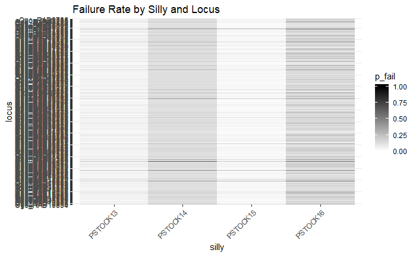

[figure not shown]

```r
failure_rate
```

We can see some very specific plate effects, we tried to address some of these QC re-runs project, but clearly some just have bad tissues. It also appears that there are a few markers that consistently fail. Also of note, 2016 had a higher failure rate that other years, I suspect that this is due to some field sampling issues from that year (i.e. evaporation of ethanol from DWPs).